# MVNSeq

S. Wotherspoon

2022-05-24

Some simple tests of the `MVNSeq` package.

```r
set.seed(31)
library(MVNSeq)
```

# Iris

Fit a simple mixture model to the `iris` data set and compare to the results from `mclust`.

```r
y <- as.matrix(log(iris[,1:4]))
```

Use kmeans to get initial class memberships, then fit a mixture model

```r
library(MVNSeq)
km <- kmeans(y,3)
fit <- mvnMix(y,km$cluster)
```

Fit equivalent mclust model

```r
library(mclust)
fit.mclust <- Mclust(y,G=3,modelNames=c("VVV"))
summary(fit.mclust,parameters=T)
```

```
## ----------------------------------------------------
## Gaussian finite mixture model fitted by EM algorithm
## ----------------------------------------------------
##
## Mclust VVV (ellipsoidal, varying volume, shape, and orientation) model with 3
## components:
##
##  log-likelihood   n df      BIC      ICL
##         399.351 150 44 578.2341 570.2944
##
## Clustering table:
##  1  2  3
## 50 50 50
##
## Mixing probabilities:
##         1         2         3
## 0.3333333 0.3335230 0.3331437
##
## Means:
##                    [,1]      [,2]      [,3]
## Sepal.Length  1.6082054 1.7886149 1.8694043
## Sepal.Width   1.2258557 1.0291605 1.0673230
## Petal.Length  0.3727587 1.4581499 1.6943406
## Petal.Width  -1.4846488 0.2810133 0.6868985
##
## Variances:
## [,,1]
##              Sepal.Length Sepal.Width Petal.Length Petal.Width
## Sepal.Length  0.004870480 0.005682252  0.002464797 0.008278210
## Sepal.Width   0.005682252 0.012443211  0.002419565 0.009375229
## Petal.Length  0.002464797 0.002419565  0.014310059 0.014944431
## Petal.Width   0.008278210 0.009375229  0.014944431 0.163683440
## [,,2]
##              Sepal.Length Sepal.Width Petal.Length Petal.Width
## Sepal.Length  0.010303410 0.008540449   0.01220843  0.01193923
## Sepal.Width   0.008540449 0.015026171   0.01246239  0.01685327
## Petal.Length  0.012208427 0.012462393   0.02024392  0.02014486
## Petal.Width   0.011939232 0.016853265   0.02014486  0.02873472
## [,,3]
##              Sepal.Length Sepal.Width Petal.Length Petal.Width
## Sepal.Length  0.008469729 0.003666960  0.007548231 0.005007579
## Sepal.Width   0.003666960 0.011738316  0.004241368 0.010410232
## Petal.Length  0.007548231 0.004241368  0.009844574 0.006629606
## Petal.Width   0.005007579 0.010410232  0.006629606 0.021445319
```

Compare classification

```r
table(max.col(fit$pars$P),fit.mclust$classification)
```

```
##
##      1  2  3
##   1 10  0  0
##   2  0 50 50
##   3 40  0  0
```

Match labels and compare means and variances

```r
j <- order(max.col(table(max.col(fit$pars$P),fit.mclust$classification)))
sapply(fit$pars$mvn[j],function(p) p$mu)
```

```
##                    [,1]       [,2]      [,3]
## Sepal.Length  1.6302081  1.6031143 1.8289866
## Sepal.Width   1.2457518  1.2212521 1.0482309
## Petal.Length  0.4330135  0.3588166 1.5761780
## Petal.Width  -0.9168073 -1.6160388 0.4838404
```

```r
lapply(fit$pars$mvn[j],function(p) p$Sigma)
```

```
## [[1]]
##              Sepal.Length Sepal.Width Petal.Length Petal.Width
## Sepal.Length  0.003861966 0.009891094  0.001953418  0.00417773
## Sepal.Width   0.009891094 0.029108661  0.008444047  0.01408589
## Petal.Length  0.001953418 0.008444047  0.013309434  0.01208424
## Petal.Width   0.004177730 0.014085890  0.012084237  0.04055815
##
## [[2]]
##              Sepal.Length  Sepal.Width Petal.Length Petal.Width
## Sepal.Length  0.004965897 0.0045836589 0.0022053777 0.005667134
## Sepal.Width   0.004583659 0.0084742902 0.0006840144 0.005066235
## Petal.Length  0.002205378 0.0006840144 0.0135071318 0.005857515
## Petal.Width   0.005667134 0.0050662352 0.0058575152 0.100300772
##
## [[3]]
##              Sepal.Length Sepal.Width Petal.Length Petal.Width
## Sepal.Length  0.011018821 0.006875874   0.01465008  0.01667318
## Sepal.Width   0.006875874 0.013747274   0.01060763  0.01750599
## Petal.Length  0.014650077 0.010607630   0.02899371  0.03735764
## Petal.Width   0.016673177 0.017505987   0.03735764  0.06627777
```

# Simulation

Simulate m sequences of q dimensional responses from a K state hidden Markov or mixture model

```r
## Number of components K, responses q and groups m
library(mvtnorm)
sim <- function(K,q,m,uscale=0,vscale=1,minl=100,meanl=500,hmm=T) {

  ## Vector of sequence lengths
  ns <- minl+rpois(m,max(meanl-minl,0))
  n <- sum(ns)

  ## Group structure
  gr <- rep(1:m,ns)
  J <- c(1,cumsum(ns))

  ## Responses, group means, population means, and covariances
  Y <- array(0,c(n,q,K))
  A <- array(0,c(m,q,K))
  Mu <- array(0,c(K,q))
  U <- vector(mode="list",K)
  V <- vector(mode="list",K)

  ## Simulate a response for each state and group
  for(k in 1:K) {
    ## Covariance of random effects
    U[[k]] <- crossprod(matrix(rnorm(q*q,0,uscale),q,q))
    ## Covariance of response about group means
    V[[k]] <- crossprod(matrix(rnorm(q*q,0,vscale),q,q))
    ## Population mean
    Mu[k,] <- runif(q,0,10)
    ## Group means
    A[,,k] <- rmvnorm(m,Mu[k,],U[[k]])
    ## Responses
    Y[,,k] <- A[gr,,k] + rmvnorm(n,rep(0,q),V[[k]])
  }

  ## state prior
  p <- runif(K)
  p <- p/sum(p)


  if(hmm) {
    ## Random transition matrix
    Q <- matrix(runif(K*K),K,K)
    Q <- Q/rowSums(Q)
  } else {
    Q <- matrix(p,K,K,byrow=T)
  }

  ## Simulate (Markovian) sequence of class membership and observations
  cl <- integer(n)
  y <- array(0,c(n,q))
  for(i in 1:m) {
    j <- J[i]
    cl[j] <- sample(K,1,prob=p)
    y[j,] <- Y[j,,cl[j]]
    for(j in (J[i]+1):J[i+1]) {
      cl[j] <- sample(K,1,prob=Q[cl[j-1],])
      y[j,] <- Y[j,,cl[j]]
    }
  }
  list(y=y,cl=cl,gr=gr,A=A,Mu=Mu,U=U,V=V,p=p,Q=Q)
}
```

## Single sequence from a 3 component Mixture

Simulate a 3 component mixture.

```r
s <- sim(K=3,q=3,m=1,hmm=F)
```

Use kmeans to get initial class memberships, then fit a mixture model

```r
km <- kmeans(s$y,3)
fit <- mvnMix(s$y,km$cluster)
```

Fit equivalent mclust model

```r
library(mclust)
fit.mclust <- Mclust(s$y,G=3,modelNames=c("VVV"))
summary(fit.mclust,parameters=T)
```

```
## ----------------------------------------------------
## Gaussian finite mixture model fitted by EM algorithm
## ----------------------------------------------------
##
## Mclust VVV (ellipsoidal, varying volume, shape, and orientation) model with 3
## components:
##
##  log-likelihood   n df       BIC      ICL
##       -2913.247 481 29 -6005.595 -6099.98
##
## Clustering table:
##   1   2   3
## 221 139 121
##
## Mixing probabilities:
##         1         2         3
## 0.4505086 0.2884524 0.2610390
##
## Means:
##          [,1]      [,2]     [,3]
## [1,] 2.945562 4.1017695 1.633788
## [2,] 9.083509 0.9191229 6.345848
## [3,] 4.209182 9.8565837 2.097516
##
## Variances:
## [,,1]
##            [,1]      [,2]       [,3]
## [1,]  2.8497032  1.545379 -0.3831208
## [2,]  1.5453791  7.967206 -2.6905005
## [3,] -0.3831208 -2.690500  3.0056490
## [,,2]
##            [,1]      [,2]       [,3]
## [1,]  0.6110964 -1.550704  0.4599090
## [2,] -1.5507045  4.771453 -1.2217400
## [3,]  0.4599090 -1.221740  0.8663531
## [,,3]
##            [,1]      [,2]       [,3]
## [1,] 1.72524914 0.5093997 0.09850337
## [2,] 0.50939972 2.2240983 0.20858488
## [3,] 0.09850337 0.2085849 2.30840630
```

Compare to mclust classification

```r
table(max.col(fit$pars$P),fit.mclust$classification)
```

```
##
##       1   2   3
##   1   0 139   0
##   2 204   0   0
##   3  17   0 121
```

Match labels and compare means and variances

```r
j <- order(max.col(table(max.col(fit$pars$P),fit.mclust$classification)))
sapply(fit$pars$mvn[j],function(p) p$mu)
```

```
##          [,1]      [,2]     [,3]
## [1,] 2.988210 4.1017362 1.755131
## [2,] 9.232132 0.9191037 6.518266
## [3,] 4.241944 9.8560758 2.341899
```

```r
lapply(fit$pars$mvn[j],function(p) p$Sigma)
```

```
## [[1]]
##            [,1]      [,2]       [,3]
## [1,]  2.9213586  1.565829 -0.4347314
## [2,]  1.5658290  8.263213 -2.9500608
## [3,] -0.4347314 -2.950061  3.0921178
##
## [[2]]
##            [,1]      [,2]       [,3]
## [1,]  0.6110664 -1.550602  0.4605798
## [2,] -1.5506019  4.770914 -1.2232579
## [3,]  0.4605798 -1.223258  0.8682789
##
## [[3]]
##           [,1]      [,2]      [,3]
## [1,] 1.8481144 0.6614116 0.2699746
## [2,] 0.6614116 2.4693060 0.3569627
## [3,] 0.2699746 0.3569627 2.6526515
```

Compare to actual classification

```r
table(max.col(fit$pars$P),s$cl)
```

```
##
##       1   2   3
##   1 139   0   0
##   2   2  29 173
##   3   0 119  19
```

Match labels and compare means

```r
j <- order(max.col(table(max.col(fit$pars$P),s$cl)))
t(s$Mu)
```

```
##           [,1]     [,2]     [,3]
## [1,] 4.0854750 1.485338 3.121242
## [2,] 0.9856953 6.575996 9.382425
## [3,] 9.7675081 2.162322 4.325996
```

```r
sapply(fit$pars$mvn[j],function(p) p$mu)
```

```
##           [,1]     [,2]     [,3]
## [1,] 4.1017362 1.755131 2.988210
## [2,] 0.9191037 6.518266 9.232132
## [3,] 9.8560758 2.341899 4.241944
```

and variances

```r
s$V
```

```
## [[1]]
##            [,1]      [,2]       [,3]
## [1,]  0.6360487 -1.580102  0.4832672
## [2,] -1.5801019  4.776093 -1.2770457
## [3,]  0.4832672 -1.277046  0.8745483
##
## [[2]]
##           [,1]      [,2]      [,3]
## [1,] 2.4032193 0.6227514 0.7268793
## [2,] 0.6227514 2.9402115 0.6379850
## [3,] 0.7268793 0.6379850 2.9142096
##
## [[3]]
##            [,1]      [,2]       [,3]
## [1,]  3.5668989  2.744795 -0.9034164
## [2,]  2.7447949  8.732531 -3.1359605
## [3,] -0.9034164 -3.135961  2.9652120
```

```r
lapply(fit$pars$mvn[j],function(p) p$Sigma)
```

```
## [[1]]
##            [,1]      [,2]       [,3]
## [1,]  0.6110664 -1.550602  0.4605798
## [2,] -1.5506019  4.770914 -1.2232579
## [3,]  0.4605798 -1.223258  0.8682789
##
## [[2]]
##           [,1]      [,2]      [,3]
## [1,] 1.8481144 0.6614116 0.2699746
## [2,] 0.6614116 2.4693060 0.3569627
## [3,] 0.2699746 0.3569627 2.6526515
##
## [[3]]
##            [,1]      [,2]       [,3]
## [1,]  2.9213586  1.565829 -0.4347314
## [2,]  1.5658290  8.263213 -2.9500608
## [3,] -0.4347314 -2.950061  3.0921178
```

## Single HHM sequence

Simulate one long sequence

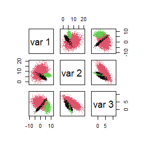

```r
s <- sim(K=3,q=3,m=1,minl=10000,hmm=T)
pairs(s$y,pch=".",col=s$cl)
```

### Mixture model

Use kmeans to get initial class memberships, then fit a mixture model

```r
km <- kmeans(s$y,3)
fit <- mvnMix(s$y,km$cluster)
```

Compare to actual classification

```r
table(max.col(fit$pars$P),s$cl)
```

```
##
##        1    2    3
##   1   24 5505    2
##   2    1    1 1515
##   3 2900   51    1
```

Match labels and compare means

```r
j <- order(max.col(table(max.col(fit$pars$P),s$cl)))
t(s$Mu)
```

```
##          [,1]       [,2]     [,3]
## [1,] 1.086333 0.09451626 6.557651
## [2,] 5.267106 9.13951924 6.266136
## [3,] 2.558561 4.19027239 1.611691
```

```r
sapply(fit$pars$mvn[j],function(p) p$mu)
```

```
##          [,1]       [,2]     [,3]
## [1,] 1.042559 0.01280498 6.585248
## [2,] 5.286715 9.13202711 6.267375
## [3,] 2.518324 4.16761305 1.592715
```

and variances

```r
s$V
```

```
## [[1]]
##           [,1]      [,2]      [,3]
## [1,]  3.084536 -2.006272  2.343617
## [2,] -2.006272  2.080410 -1.599316
## [3,]  2.343617 -1.599316  2.072405
##
## [[2]]
##            [,1]      [,2]       [,3]
## [1,]  8.0712377  2.687176 -0.9199051
## [2,]  2.6871758 10.513295 -4.1756820
## [3,] -0.9199051 -4.175682  2.9279203
##
## [[3]]
##            [,1]       [,2]       [,3]
## [1,]  1.8942602 -0.3337778 -0.1452044
## [2,] -0.3337778  0.5829047 -1.1508488
## [3,] -0.1452044 -1.1508488  2.6578544
```

```r
lapply(fit$pars$mvn[j],function(p) p$Sigma)
```

```
## [[1]]
##           [,1]      [,2]      [,3]
## [1,]  3.010025 -1.972045  2.304823
## [2,] -1.972045  2.041684 -1.574385
## [3,]  2.304823 -1.574385  2.048570
##
## [[2]]
##            [,1]      [,2]       [,3]
## [1,]  8.2298235  2.836245 -0.9944135
## [2,]  2.8362452 10.580016 -4.1526961
## [3,] -0.9944135 -4.152696  2.9474754
##
## [[3]]
##            [,1]       [,2]       [,3]
## [1,]  1.8575275 -0.3105523 -0.1776459
## [2,] -0.3105523  0.5804482 -1.1547459
## [3,] -0.1776459 -1.1547459  2.6772098
```

### HMM

Use kmeans to get initial class memberships, then fit an hidden Markov model

```r
km <- kmeans(s$y,3)
fit <- mvnHMM(s$y,km$cluster)
```

Compare to actual classification

```r
table(max.col(fit$pars$P),s$cl)
```

```
##
##        1    2    3
##   1 2902   53    1
##   2   21 5504    3
##   3    2    0 1514
```

Match labels and compare means

```r
j <- order(max.col(table(max.col(fit$pars$P),s$cl)))
t(s$Mu)
```

```
##          [,1]       [,2]     [,3]
## [1,] 1.086333 0.09451626 6.557651
## [2,] 5.267106 9.13951924 6.266136
## [3,] 2.558561 4.19027239 1.611691
```

```r
sapply(fit$pars$mvn[j],function(p) p$mu)
```

```
##          [,1]       [,2]     [,3]
## [1,] 1.043743 0.01180117 6.584700
## [2,] 5.286607 9.13354819 6.267555
## [3,] 2.519434 4.16774027 1.592599
```

and variances

```r
s$V
```

```
## [[1]]
##           [,1]      [,2]      [,3]
## [1,]  3.084536 -2.006272  2.343617
## [2,] -2.006272  2.080410 -1.599316
## [3,]  2.343617 -1.599316  2.072405
##
## [[2]]
##            [,1]      [,2]       [,3]
## [1,]  8.0712377  2.687176 -0.9199051
## [2,]  2.6871758 10.513295 -4.1756820
## [3,] -0.9199051 -4.175682  2.9279203
##
## [[3]]
##            [,1]       [,2]       [,3]
## [1,]  1.8942602 -0.3337778 -0.1452044
## [2,] -0.3337778  0.5829047 -1.1508488
## [3,] -0.1452044 -1.1508488  2.6578544
```

```r
lapply(fit$pars$mvn[j],function(p) p$Sigma)
```

```
## [[1]]
##           [,1]      [,2]      [,3]
## [1,]  3.009821 -1.969798  2.303824
## [2,] -1.969798  2.039575 -1.573023
## [3,]  2.303824 -1.573023  2.048411
##
## [[2]]
##            [,1]      [,2]       [,3]
## [1,]  8.2306372  2.840667 -0.9937869
## [2,]  2.8406666 10.578730 -4.1550536
## [3,] -0.9937869 -4.155054  2.9489410
##
## [[3]]
##            [,1]       [,2]       [,3]
## [1,]  1.8602502 -0.3109706 -0.1780499
## [2,] -0.3109706  0.5801423 -1.1538884
## [3,] -0.1780499 -1.1538884  2.6755620
```

and transition probabilities

```r
fit$Q[j,j]
```

[output not shown]

```r
s$Q
```

```
##           [,1]      [,2]       [,3]
## [1,] 0.5013823 0.4388176 0.05980009
## [2,] 0.1724856 0.6340568 0.19345761
## [3,] 0.3003886 0.5415018 0.15810962
```

## Multiple HHM Sequence

Simulate many shorter sequences all with varying means

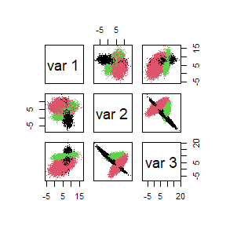

```r
s <- sim(K=3,q=3,m=100,minl=100,meanl=500,hmm=T,uscale = 0.8)
pairs(s$y,pch=".",col=s$cl)
```

### Fixed Effects Mixture Model

Use kmeans to get initial class memberships, but use actual means to avoid label permutation issues, then fit a mixture model to each sequence forcing common mixing fractions across sequences

```r
km <- kmeans(s$y,s$Mu)
fit <- gmvnMix(s$y,km$cluster,s$gr,common.fractions = TRUE)
```

Compare classifications across all groups

```r
table(unlist(lapply(fit$pars,function(p) max.col(p$P))),s$cl)
```

```
##
##         1     2     3
##   1 13163    41   321
##   2   176 22877     3
##   3   827    23 12287
```

Compare group means

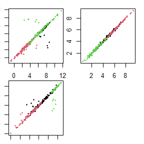

```r
## Check parameter estimates match simulation
opar <- par(mfrow=c(2,2),mar=c(1,1,1,1)+0.1)
matplot(s$A[,,1],t(sapply(fit$pars,function(p) p$mvn[[1]]$mu)),pch=16,cex=0.5,xlab="",ylab="")
matplot(s$A[,,2],t(sapply(fit$pars,function(p) p$mvn[[2]]$mu)),pch=16,cex=0.5,xlab="",ylab="")
matplot(s$A[,,3],t(sapply(fit$pars,function(p) p$mvn[[3]]$mu)),pch=16,cex=0.5,xlab="",ylab="")
par(opar)
```

Compare covariances

```r
fit$pars[[1]]$mvn[[1]]$Sigma
```

```
##            [,1]       [,2]       [,3]
## [1,]  0.9600496 -0.6965665  0.8068133
## [2,] -0.6965665  5.5786767 -5.6301046
## [3,]  0.8068133 -5.6301046  5.7568689
```

```r
s$V[[1]]
```

```
##            [,1]       [,2]       [,3]
## [1,]  0.9393509 -0.6951404  0.8039255
## [2,] -0.6951404  5.6224343 -5.6769751
## [3,]  0.8039255 -5.6769751  5.8044153
```

```r
fit$pars[[1]]$mvn[[2]]$Sigma
```

```
##           [,1]      [,2]     [,3]
## [1,] 5.1670498 0.2315446 3.410331
## [2,] 0.2315446 1.4533423 2.367112
## [3,] 3.4103310 2.3671116 5.660019
```

```r
s$V[[2]]
```

```
##           [,1]      [,2]     [,3]
## [1,] 5.2063151 0.2528132 3.465387
## [2,] 0.2528132 1.4422909 2.362094
## [3,] 3.4653875 2.3620943 5.683514
```

```r
fit$pars[[1]]$mvn[[3]]$Sigma
```

```
##           [,1]        [,2]        [,3]
## [1,] 3.8140705  0.71893069  0.25106824
## [2,] 0.7189307  2.04915079 -0.03520764
## [3,] 0.2510682 -0.03520764  1.65828737
```

```r
s$V[[3]]
```

```
##           [,1]      [,2]      [,3]
## [1,] 3.7085186 0.7204926 0.5651862
## [2,] 0.7204926 1.7292273 0.4907360
## [3,] 0.5651862 0.4907360 0.7512749
```

### Fixed Effects Hidden Markov Model

Use kmeans to get initial class memberships, but use actual means to avoid label permutation issues, then fit a hidden Markov model to each sequence forcing common transition probabilities across sequences

```r
km <- kmeans(s$y,s$Mu)
fit <- gmvnHMM(s$y,km$cluster,s$gr,common.transition = TRUE)
```

Compare classifications across all groups

```r
table(unlist(lapply(fit$pars,function(p) max.col(p$P))),s$cl)
```

```
##
##         1     2     3
##   1 13215    48   291
##   2   116 22874     0
##   3   835    19 12320
```

Compare group means

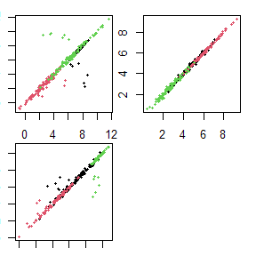

```r
## Check parameter estimates match simulation
opar <- par(mfrow=c(2,2),mar=c(1,1,1,1)+0.1)
matplot(s$A[,,1],t(sapply(fit$pars,function(p) p$mvn[[1]]$mu)),pch=16,cex=0.5,xlab="",ylab="")
matplot(s$A[,,2],t(sapply(fit$pars,function(p) p$mvn[[2]]$mu)),pch=16,cex=0.5,xlab="",ylab="")
matplot(s$A[,,3],t(sapply(fit$pars,function(p) p$mvn[[3]]$mu)),pch=16,cex=0.5,xlab="",ylab="")
par(opar)
```

Compare covariances

```r
fit$pars[[1]]$mvn[[1]]$Sigma
```

```
##            [,1]       [,2]       [,3]
## [1,]  0.9570033 -0.6984707  0.8086874
## [2,] -0.6984707  5.5892589 -5.6411141
## [3,]  0.8086874 -5.6411141  5.7677962
```

```r
s$V[[1]]
```

```
##            [,1]       [,2]       [,3]
## [1,]  0.9393509 -0.6951404  0.8039255
## [2,] -0.6951404  5.6224343 -5.6769751
## [3,]  0.8039255 -5.6769751  5.8044153
```

```r
fit$pars[[1]]$mvn[[2]]$Sigma
```

```
##          [,1]     [,2]     [,3]
## [1,] 5.177193 0.236711 3.424177
## [2,] 0.236711 1.454567 2.372122
## [3,] 3.424177 2.372122 5.675957
```

```r
s$V[[2]]
```

```
##           [,1]      [,2]     [,3]
## [1,] 5.2063151 0.2528132 3.465387
## [2,] 0.2528132 1.4422909 2.362094
## [3,] 3.4653875 2.3620943 5.683514
```

```r
fit$pars[[1]]$mvn[[3]]$Sigma
```

```
##           [,1]        [,2]        [,3]
## [1,] 3.8118696  0.71859661  0.24855928
## [2,] 0.7185966  2.04664095 -0.03837645
## [3,] 0.2485593 -0.03837645  1.67341207
```

```r
s$V[[3]]
```

```
##           [,1]      [,2]      [,3]
## [1,] 3.7085186 0.7204926 0.5651862
## [2,] 0.7204926 1.7292273 0.4907360
## [3,] 0.5651862 0.4907360 0.7512749
```

Compare transition probabilities

```r
fit$pars[[1]]$Q
```

```
##           [,1]      [,2]       [,3]
## [1,] 0.2734859 0.6921932 0.03432091
## [2,] 0.3469748 0.2114656 0.44155965
## [3,] 0.1392366 0.6577995 0.20296397
```

```r
s$Q
```

```
##           [,1]      [,2]       [,3]
## [1,] 0.2787591 0.6918734 0.02936753
## [2,] 0.3624129 0.2104785 0.42710864
## [3,] 0.1512053 0.6594140 0.18938071
```

### Random Effects Mixture Model

Use kmeans to get initial class memberships, but use actual means to avoid label permutation issues, then fit a mixture model to each sequence forcing common mixing fractions across sequences

```r
km <- kmeans(s$y,s$Mu)
fit <- grmvnMix(s$y,km$cluster,s$gr,common.fractions = TRUE)
```

Compare classifications across all groups

```r
table(unlist(lapply(fit$pars,function(p) max.col(p$P))),s$cl)
```

```
##
##         1     2     3
##   1 13296    40   292
##   2   176 22879     3
##   3   694    22 12316
```

Compare group means

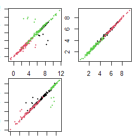

```r
## Check parameter estimates match simulation
opar <- par(mfrow=c(2,2),mar=c(1,1,1,1)+0.1)
matplot(s$A[,,1],t(sapply(fit$pars,function(p) p$mvn[[1]]$mu)),pch=16,cex=0.5,xlab="",ylab="")
matplot(s$A[,,2],t(sapply(fit$pars,function(p) p$mvn[[2]]$mu)),pch=16,cex=0.5,xlab="",ylab="")
matplot(s$A[,,3],t(sapply(fit$pars,function(p) p$mvn[[3]]$mu)),pch=16,cex=0.5,xlab="",ylab="")
par(opar)
```

Compare covariances

```r
fit$pars[[1]]$mvn[[1]]$Sigma
```

```
##            [,1]       [,2]       [,3]
## [1,]  0.9660406 -0.7002619  0.8109872
## [2,] -0.7002619  5.6209618 -5.6730812
## [3,]  0.8109872 -5.6730812  5.8010509
```

```r
s$V[[1]]
```

```
##            [,1]       [,2]       [,3]
## [1,]  0.9393509 -0.6951404  0.8039255
## [2,] -0.6951404  5.6224343 -5.6769751
## [3,]  0.8039255 -5.6769751  5.8044153
```

```r
fit$pars[[1]]$mvn[[2]]$Sigma
```

```
##           [,1]      [,2]     [,3]
## [1,] 5.1930204 0.2330911 3.428079
## [2,] 0.2330911 1.4603784 2.378830
## [3,] 3.4280790 2.3788300 5.688562
```

```r
s$V[[2]]
```

```
##           [,1]      [,2]     [,3]
## [1,] 5.2063151 0.2528132 3.465387
## [2,] 0.2528132 1.4422909 2.362094
## [3,] 3.4653875 2.3620943 5.683514
```

```r
fit$pars[[1]]$mvn[[3]]$Sigma
```

```
##           [,1]       [,2]       [,3]
## [1,] 3.8200515 0.73448708 0.30764074
## [2,] 0.7344871 2.03592289 0.01671447
## [3,] 0.3076407 0.01671447 1.58038493
```

```r
s$V[[3]]
```

```
##           [,1]      [,2]      [,3]
## [1,] 3.7085186 0.7204926 0.5651862
## [2,] 0.7204926 1.7292273 0.4907360
## [3,] 0.5651862 0.4907360 0.7512749
```

Compare covariances of group means

```r
fit$muv[[1]]$U
```

```
##            [,1]       [,2]       [,3]
## [1,]  0.7192098 -0.2572025 -0.1059888
## [2,] -0.2572025  1.7493307 -2.2977552
## [3,] -0.1059888 -2.2977552  3.9154455
```

```r
s$U[[1]]
```

```
##            [,1]       [,2]       [,3]
## [1,]  0.3062235 -0.2878761  0.3066618
## [2,] -0.2878761  1.8914922 -2.6611649
## [3,]  0.3066618 -2.6611649  4.1509031
```

```r
fit$muv[[2]]$U
```

```
##            [,1]       [,2]       [,3]
## [1,]  1.0885124 -0.6205009 -0.4547274
## [2,] -0.6205009  1.3685139  0.8645794
## [3,] -0.4547274  0.8645794  0.8698073
```

```r
s$U[[2]]
```

```
##            [,1]       [,2]       [,3]
## [1,]  1.0599629 -0.6517513 -0.4803685
## [2,] -0.6517513  1.2551901  0.8220327
## [3,] -0.4803685  0.8220327  1.0411222
```

```r
fit$muv[[3]]$U
```

```
##           [,1]      [,2]      [,3]
## [1,] 2.0713084 1.9497108 0.4880887
## [2,] 1.9497108 1.9916467 0.4750841
## [3,] 0.4880887 0.4750841 0.7917677
```

```r
s$U[[3]]
```

```
##           [,1]      [,2]      [,3]
## [1,] 2.5127474 2.4131857 0.4199897
## [2,] 2.4131857 2.3852437 0.3778228
## [3,] 0.4199897 0.3778228 0.1715572
```

### Random Effects Hidden Markov Model

Use kmeans to get initial class memberships, but use actual means to avoid label permutation issues, then fit a hidden Markov model to each sequence forcing common transition probabilities across sequences

```r
km <- kmeans(s$y,s$Mu)
fit <- grmvnHMM(s$y,km$cluster,s$gr,common.transition = TRUE)
```

Compare classifications across all groups

```r
table(unlist(lapply(fit$pars,function(p) max.col(p$P))),s$cl)
```

```
##
##         1     2     3
##   1 13349    47   270
##   2   115 22876     0
##   3   702    18 12341
```

Compare group means

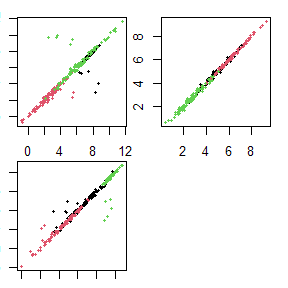

```r
## Check parameter estimates match simulation
opar <- par(mfrow=c(2,2),mar=c(1,1,1,1)+0.1)
matplot(s$A[,,1],t(sapply(fit$pars,function(p) p$mvn[[1]]$mu)),pch=16,cex=0.5,xlab="",ylab="")
matplot(s$A[,,2],t(sapply(fit$pars,function(p) p$mvn[[2]]$mu)),pch=16,cex=0.5,xlab="",ylab="")
matplot(s$A[,,3],t(sapply(fit$pars,function(p) p$mvn[[3]]$mu)),pch=16,cex=0.5,xlab="",ylab="")
par(opar)
```

Compare covariances

```r
fit$pars[[1]]$mvn[[1]]$Sigma
```

```
##            [,1]       [,2]       [,3]
## [1,]  0.9633667 -0.7020381  0.8126584
## [2,] -0.7020381  5.6305765 -5.6827641
## [3,]  0.8126584 -5.6827641  5.8103040
```

```r
s$V[[1]]
```

```
##            [,1]       [,2]       [,3]
## [1,]  0.9393509 -0.6951404  0.8039255
## [2,] -0.6951404  5.6224343 -5.6769751
## [3,]  0.8039255 -5.6769751  5.8044153
```

```r
fit$pars[[1]]$mvn[[2]]$Sigma
```

```
##           [,1]      [,2]     [,3]
## [1,] 5.2019834 0.2379532 3.440748
## [2,] 0.2379532 1.4614032 2.383345
## [3,] 3.4407480 2.3833451 5.703021
```

```r
s$V[[2]]
```

```
##           [,1]      [,2]     [,3]
## [1,] 5.2063151 0.2528132 3.465387
## [2,] 0.2528132 1.4422909 2.362094
## [3,] 3.4653875 2.3620943 5.683514
```

```r
fit$pars[[1]]$mvn[[3]]$Sigma
```

```
##           [,1]       [,2]       [,3]
## [1,] 3.8183707 0.73687458 0.30573989
## [2,] 0.7368746 2.03434147 0.01248903
## [3,] 0.3057399 0.01248903 1.59389869
```

```r
s$V[[3]]
```

```
##           [,1]      [,2]      [,3]
## [1,] 3.7085186 0.7204926 0.5651862
## [2,] 0.7204926 1.7292273 0.4907360
## [3,] 0.5651862 0.4907360 0.7512749
```

Compare covariances of group means

```r
fit$muv[[1]]$U
```

```
##            [,1]       [,2]       [,3]
## [1,]  0.7392143 -0.2722172 -0.1225613
## [2,] -0.2722172  1.7420354 -2.2917626
## [3,] -0.1225613 -2.2917626  3.9238625
```

```r
s$U[[1]]
```

```
##            [,1]       [,2]       [,3]
## [1,]  0.3062235 -0.2878761  0.3066618
## [2,] -0.2878761  1.8914922 -2.6611649
## [3,]  0.3066618 -2.6611649  4.1509031
```

```r
fit$muv[[2]]$U
```

```
##            [,1]       [,2]       [,3]
## [1,]  1.0904056 -0.6214872 -0.4551217
## [2,] -0.6214872  1.3684953  0.8648161
## [3,] -0.4551217  0.8648161  0.8711351
```

```r
s$U[[2]]
```

```
##            [,1]       [,2]       [,3]
## [1,]  1.0599629 -0.6517513 -0.4803685
## [2,] -0.6517513  1.2551901  0.8220327
## [3,] -0.4803685  0.8220327  1.0411222
```

```r
fit$muv[[3]]$U
```

```
##           [,1]      [,2]      [,3]
## [1,] 2.0672723 1.9476188 0.4910003
## [2,] 1.9476188 1.9900042 0.4771539
## [3,] 0.4910003 0.4771539 0.7812775
```

```r
s$U[[3]]
```

```
##           [,1]      [,2]      [,3]
## [1,] 2.5127474 2.4131857 0.4199897
## [2,] 2.4131857 2.3852437 0.3778228
## [3,] 0.4199897 0.3778228 0.1715572
```

Compare transition probabilities

```r
fit$pars[[1]]$Q
```

```
##           [,1]      [,2]       [,3]
## [1,] 0.2734452 0.6927252 0.03382958
## [2,] 0.3500796 0.2114935 0.43842696
## [3,] 0.1418832 0.6568826 0.20123415
```

```r
s$Q
```

```
##           [,1]      [,2]       [,3]
## [1,] 0.2787591 0.6918734 0.02936753
## [2,] 0.3624129 0.2104785 0.42710864
## [3,] 0.1512053 0.6594140 0.18938071
```